# Bayesian regression project

## Setup

### Load packages

```r
library(ggplot2)
library(dplyr)
library(statsr)
library(BAS)
library(GGally)
```

### Load data

```r
load("movies.Rdata")
```

## Part 1: Data

- **Generalizability** to movies outside of this database is possible thanks to the practice of random sampling.
- It is not possible to establish a link of **causality** between different variables because random assignment was not used.

## Part 2: Data manipulation

Many of the variables contained in the initial database can not be considered explanatory with respect to `audience_score`. For this reason, we are going to work with the following subset of variables.

```r
movies <- dplyr::select(movies, audience_score, title_type, genre, mpaa_rating, thtr_rel_month, runtime, thtr_rel_year, imdb_rating, imdb_num_votes, critics_score, best_pic_nom, best_pic_win, best_actor_win, best_actress_win, best_dir_win, top200_box)
```

Then, we will create five new categorical variables. The first is `feature_film` with levels yes (movies that are feature films) and no.

```r
movies <- mutate(movies, feature_film = as.factor(ifelse(title_type == 'Feature Film', "yes", "no")))
```

The second is `drama` with levels yes (movies that are dramas) and no.

```r
movies <- mutate(movies, drama = as.factor(ifelse(genre == 'Drama', "yes", "no")))
```

The third is `mpaa_rating_R` with levels yes (movies that are meant for restricted audiences) and no.

```r
movies <- mutate(movies, mpaa_rating_R = as.factor(ifelse(mpaa_rating == 'R', "yes", "no")))
```

The fourth is `oscar_season` with levels yes (if movie is released in October, November or December) and no.

```r
movies <- mutate(movies, oscar_season = as.factor(ifelse((thtr_rel_month >= 10) & (thtr_rel_month <= 12), "yes", "no")))
```

The fifth and final is `summer_season` with levels yes (if movie is released in May, June, July, or August) and no.

```r
movies <- mutate(movies, summer_season = as.factor(ifelse((thtr_rel_month >= 5) & (thtr_rel_month <= 8), "yes", "no")))
```

The variables `title_type`, `genre`, `mpaa_rating` and `thtr_rel_month` can be dropped from the reduced database.

```r
movies <- dplyr::select(movies, audience_score, feature_film, drama, mpaa_rating_R, oscar_season, summer_season, runtime, thtr_rel_year, imdb_rating, imdb_num_votes, critics_score, best_pic_nom, best_pic_win, best_actor_win, best_actress_win, best_dir_win, top200_box)
```

## Part 3: Exploratory data analysis

The following summary of the `movies` database shows that it is composed of 6 numerical and 11 categorical variables.

```r
summary(movies)
```

```
##  audience_score  feature_film drama     mpaa_rating_R oscar_season
##  Min.   :11.00   no : 60      no :346   no :322       no :460
##  1st Qu.:46.00   yes:591      yes:305   yes:329       yes:191
##  Median :65.00
##  Mean   :62.36
##  3rd Qu.:80.00
##  Max.   :97.00
##
##  summer_season    runtime      thtr_rel_year   imdb_rating
##  no :443       Min.   : 39.0   Min.   :1970   Min.   :1.900
##  yes:208       1st Qu.: 92.0   1st Qu.:1990   1st Qu.:5.900
##                Median :103.0   Median :2000   Median :6.600
##                Mean   :105.8   Mean   :1998   Mean   :6.493
##                3rd Qu.:115.8   3rd Qu.:2007   3rd Qu.:7.300
##                Max.   :267.0   Max.   :2014   Max.   :9.000
##                NA's   :1
##  imdb_num_votes   critics_score    best_pic_nom best_pic_win
##  Min.   :   180   Min.   :  1.00   no :629      no :644
##  1st Qu.:  4546   1st Qu.: 33.00   yes: 22      yes:  7
##  Median : 15116   Median : 61.00
##  Mean   : 57533   Mean   : 57.69
##  3rd Qu.: 58300   3rd Qu.: 83.00
##  Max.   :893008   Max.   :100.00
##
##  best_actor_win best_actress_win best_dir_win top200_box
##  no :558        no :579          no :608      no :636
##  yes: 93        yes: 72          yes: 43      yes: 15
##
##
##
##
##
```

The variable of interest is `audience_score`, whereas all the other variables are potential explanatory variables. It is interesting to plot the distribution of `audience_score` with a histogram.

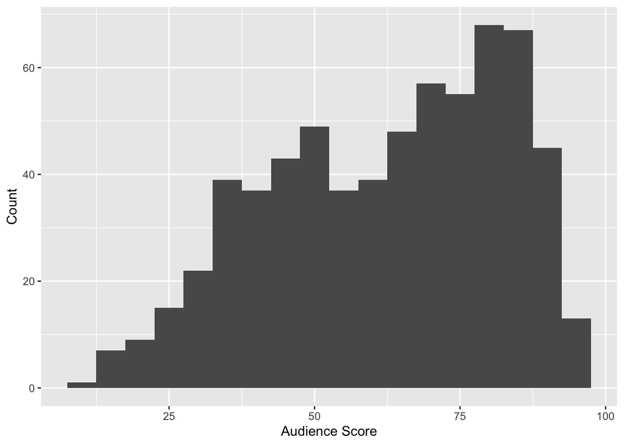

```r
ggplot(data = movies, aes(x = audience_score)) +
  geom_histogram(binwidth = 5) + labs(x = 'Audience Score', y = 'Count')
```

It appears that `audience_score` has a bimodal left-skewed distribution, with two peaks around 50% and 80%, respectively. There are relatively few movies that the public utterly dislikes. Does this mean that people are more willing to rate a movie on *Rotten Tomatoes* when they liked it? This may be a source of bias in the results.

The relationship between `audience_score` and the new variables defined in the previous section can be investigated by calculating summary statistics and using box plots. The following box plots will show also the mean of the distribution with a rhomb symbol.

```r
by(movies$audience_score,movies$feature_film,summary)
```

```
## movies$feature_film: no
##    Min. 1st Qu.  Median    Mean 3rd Qu.    Max.
##   19.00   76.50   85.50   81.05   89.00   96.00
## --------------------------------------------------------
## movies$feature_film: yes
##    Min. 1st Qu.  Median    Mean 3rd Qu.    Max.
##   11.00   44.50   62.00   60.47   78.00   97.00
```

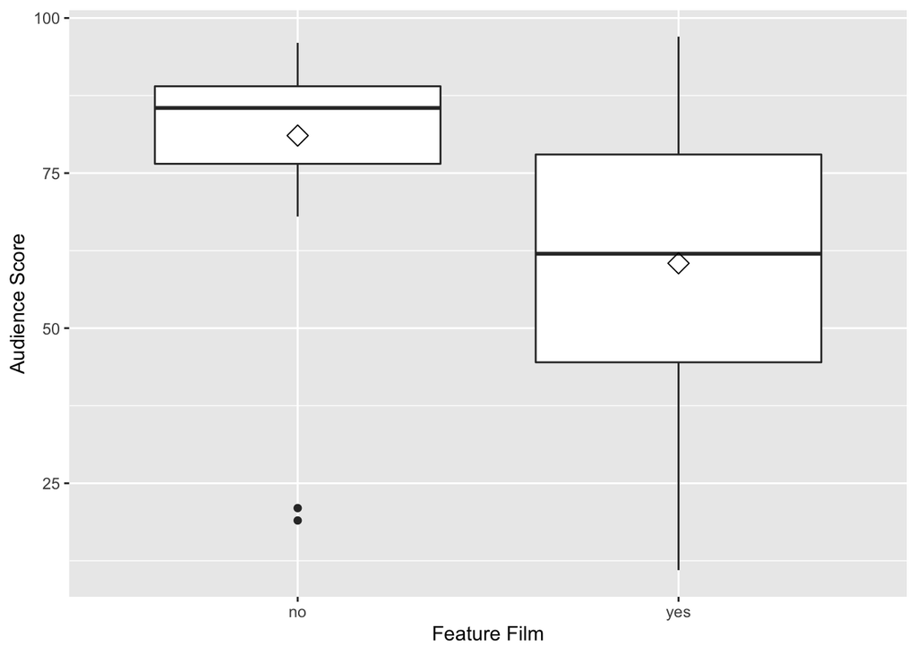

```r
ggplot(data = movies, aes(x= feature_film, y = audience_score)) +
  geom_boxplot() + stat_summary(fun.y=mean, geom="point", shape=23, size=4) +
  labs(x = 'Feature Film', y = 'Audience Score')
```

The box plots show that, except for a couple of outliers, non-feature films tend to have a much higher `audience_score` than feature films. This is then a good candidate explanatory variable.

Then we can analyze the difference between drama and non-drama movies.

```r
by(movies$audience_score, movies$drama, summary)
```

```
## movies$drama: no
##    Min. 1st Qu.  Median    Mean 3rd Qu.    Max.
##   11.00   41.00   61.00   59.73   79.00   97.00
## --------------------------------------------------------
## movies$drama: yes
##    Min. 1st Qu.  Median    Mean 3rd Qu.    Max.
##   13.00   52.00   70.00   65.35   80.00   95.00
```

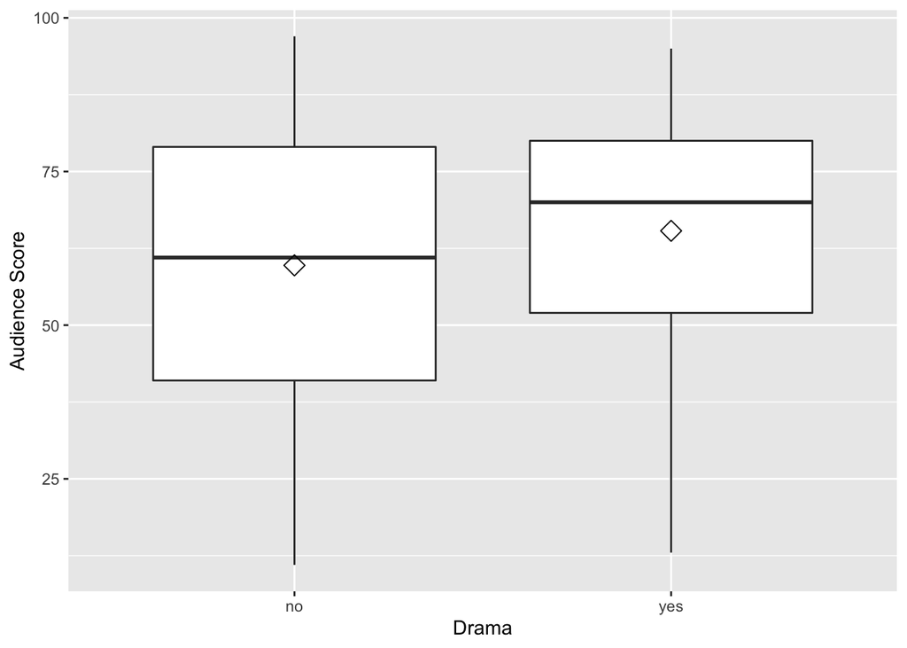

```r
ggplot(data = movies, aes(x= drama, y = audience_score)) +
  geom_boxplot() + stat_summary(fun.y=mean, geom="point", shape=23, size=4) +
  labs(x = 'Drama', y = 'Audience Score')
```

Although the minimum and maximum values are almost the same for the two categories, it can be seen that the distribution of `audience_score` of drama movies is much more left skewed.

Next, we can visualize the relationship of the variable of interest with the MPAA R-rating.

```r
by(movies$audience_score, movies$mpaa_rating_R, summary)
```

```
## movies$mpaa_rating_R: no
##    Min. 1st Qu.  Median    Mean 3rd Qu.    Max.
##   11.00   48.25   65.50   62.69   80.00   96.00
## --------------------------------------------------------
## movies$mpaa_rating_R: yes
##    Min. 1st Qu.  Median    Mean 3rd Qu.    Max.
##   14.00   44.00   64.00   62.04   79.00   97.00
```

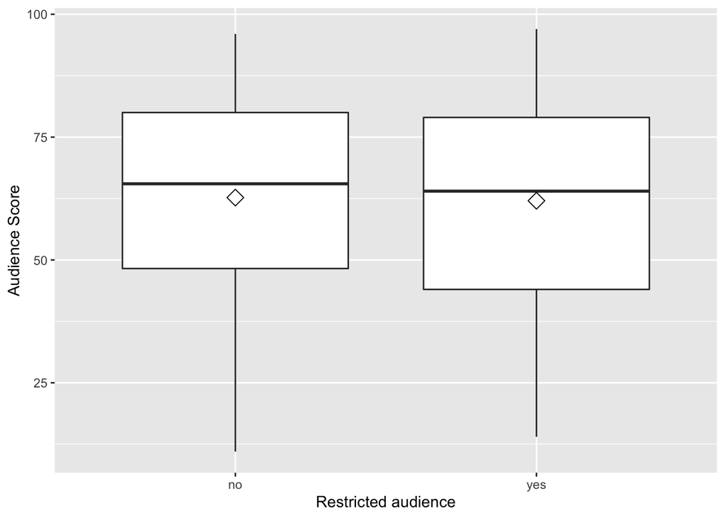

```r
ggplot(data = movies, aes(x= mpaa_rating_R, y = audience_score)) +
  geom_boxplot() + stat_summary(fun.y=mean, geom="point", shape=23, size=4) +
  labs(x = 'Restricted audience', y = 'Audience Score')
```

The R-rating does not seem to have a major correlation with the `audience_score`, except for the fact that the upper limit of the first quantile of R-rated movies is slightly lower than that of non R-rated movies.

It can be noticed that `summer_season` and `oscar_season` are mutually exclusive variables. For this reason, the distribution of `audience_score` of movies released either in the summer season, or in the Oscar season or during the rest of the year can be studied at the same time. For this purpose, we will define a new variable called `season` with levels Summer, Oscar or Other.

```r
new_movies <- transmute(movies, season = as.factor(ifelse(summer_season == 'yes', 'Summer', ifelse(oscar_season == 'yes', 'Oscar' ,"Other"))))

new_movies['audience_score'] <- movies$audience_score

by(new_movies$audience_score, new_movies$season, summary)
```

```
## new_movies$season: Oscar
##    Min. 1st Qu.  Median    Mean 3rd Qu.    Max.
##   13.00   47.50   69.00   63.69   81.00   97.00
## --------------------------------------------------------
## new_movies$season: Other
##    Min. 1st Qu.  Median    Mean 3rd Qu.    Max.
##   14.00   46.00   63.00   61.82   80.00   96.00
## --------------------------------------------------------
## new_movies$season: Summer
##    Min. 1st Qu.  Median    Mean 3rd Qu.    Max.
##   11.00   44.75   65.00   61.81   78.00   94.00
```

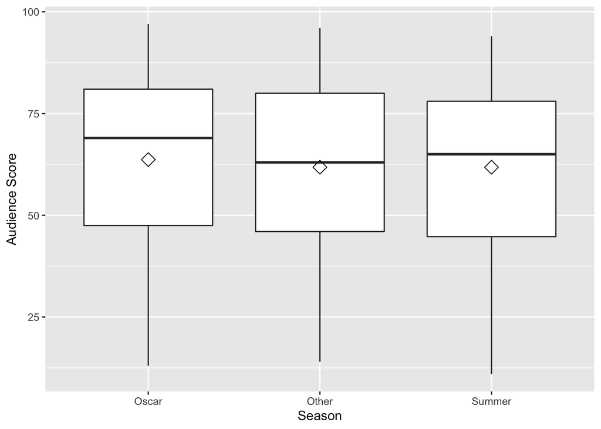

```r
ggplot(new_movies, aes(x=season, y=audience_score)) +
  geom_boxplot() + stat_summary(fun.y=mean, geom="point", shape=23, size=4) +
  labs(x = 'Season', y = 'Audience Score')
```

The season in which the movie is released does not appear to be highly correlated with its audience score, except for the fact that the distribution of `audience_score` of movies released in the Oscar season is more left skewed. Could this be due to the fact that studios tend to release their better movies during the Oscar season?

Finally, we can use the `ggpairs` function to visualize the scatter plots of each pair of numerical variables in the database, the distribution of the single variables, and the correlation coefficient of each pair.

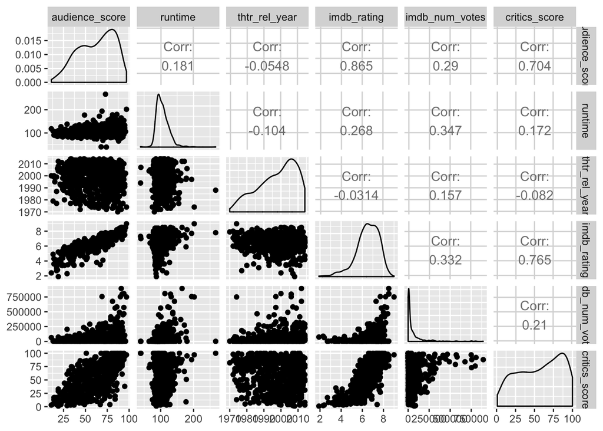

```r
ggpairs(na.omit(movies), columns = c(1,7,8,9,10,11))
```

The `audience_score` is most noticeably collinear with the `imdb_rating` and the `critics_score` variables. The first case is not surprising, since `audience_score` and `imdb_rating` represent the same thing on two different web sites and with two different scales. The second result is perhaps more interesting, because it shows that the tastes of the public and of the critics are somewhat aligned.

## Part 4: Modeling

### Model training

Given that there are $16$ candidate explanatory variables, there are $2^{16} = 65536$ possible linear models of the `audience_score`. The space of possible models will be explored by means of the `bas.lm` function - Bayesian Adaptive Sampling (BAS) for Bayesian Model Averaging and Variable Selection in Linear Models - available in the `BAS` package. In the following application of the `bas.lm` algorithm, each model has a uniform prior probability equal to $1/2^{16}$. This is therefore a non-informative prior, which is used as a starting point in absence of more detailed information. The prior distribution for regression coefficients corresponds to the Bayesian Information Criterion (BIC), which includes a penalty function depending on the number of regression parameters.

```r
# Filter out the lines containing one or more NA value
movies_no_na <- na.omit(movies)

# Fit the model using Bayesian linear regression, `bas.lm` function in the `BAS` package
bma_audience <- bas.lm(audience_score ~ . , data = movies_no_na,
                   prior = "BIC",
                   modelprior = uniform())
```

The application of the `summary` function to the results of the Bayesian regression outputs a table containing a wealth of useful information. The first column corresponds to the posterior inclusion probability of each model coefficient given the training data set. The following columns correspond to the first five linear regression models with highest posterior probability (`PostProbs`) in descending order. The zeros and ones indicate if a variable is present in the model or not. Other values tabulated for each model are the Bayes factor (`BF`) of the model with respect to the Highest Probability Model (HPM), the R-squared (`R2`) in the ordinary least squares sense, the number of variables (`dim`) and the log of marginal likelihood (`logmarg`).

```r
# Top 5 most probable models
summary(bma_audience)
```

```
##                     P(B != 0 | Y)    model 1       model 2       model 3
## Intercept              1.00000000     1.0000     1.0000000     1.0000000
## feature_filmyes        0.06536947     0.0000     0.0000000     0.0000000
## dramayes               0.04319833     0.0000     0.0000000     0.0000000
## mpaa_rating_Ryes       0.19984016     0.0000     0.0000000     0.0000000
## oscar_seasonyes        0.07505684     0.0000     0.0000000     0.0000000
## summer_seasonyes       0.08042023     0.0000     0.0000000     0.0000000
## runtime                0.46971477     1.0000     0.0000000     0.0000000
## thtr_rel_year          0.09068970     0.0000     0.0000000     0.0000000
## imdb_rating            1.00000000     1.0000     1.0000000     1.0000000
## imdb_num_votes         0.05773502     0.0000     0.0000000     0.0000000
## critics_score          0.88855056     1.0000     1.0000000     1.0000000
## best_pic_nomyes        0.13119140     0.0000     0.0000000     0.0000000
## best_pic_winyes        0.03984766     0.0000     0.0000000     0.0000000
## best_actor_winyes      0.14434896     0.0000     0.0000000     1.0000000
## best_actress_winyes    0.14128087     0.0000     0.0000000     0.0000000
## best_dir_winyes        0.06693898     0.0000     0.0000000     0.0000000
## top200_boxyes          0.04762234     0.0000     0.0000000     0.0000000
## BF                             NA     1.0000     0.9968489     0.2543185
## PostProbs                      NA     0.1297     0.1293000     0.0330000
## R2                             NA     0.7549     0.7525000     0.7539000
## dim                            NA     4.0000     3.0000000     4.0000000
## logmarg                        NA -3615.2791 -3615.2822108 -3616.6482224
##                           model 4       model 5
## Intercept               1.0000000     1.0000000
## feature_filmyes         0.0000000     0.0000000
## dramayes                0.0000000     0.0000000
## mpaa_rating_Ryes        1.0000000     1.0000000
## oscar_seasonyes         0.0000000     0.0000000
## summer_seasonyes        0.0000000     0.0000000
## runtime                 0.0000000     1.0000000
## thtr_rel_year           0.0000000     0.0000000
## imdb_rating             1.0000000     1.0000000
## imdb_num_votes          0.0000000     0.0000000
## critics_score           1.0000000     1.0000000
## best_pic_nomyes         0.0000000     0.0000000
## best_pic_winyes         0.0000000     0.0000000
## best_actor_winyes       0.0000000     0.0000000
## best_actress_winyes     0.0000000     0.0000000
## best_dir_winyes         0.0000000     0.0000000
## top200_boxyes           0.0000000     0.0000000
## BF                      0.2521327     0.2391994
## PostProbs               0.0327000     0.0310000
## R2                      0.7539000     0.7563000
## dim                     4.0000000     5.0000000
## logmarg             -3616.6568544 -3616.7095127
```

It can be seen that the top two models have posterior probability around $13\%$, which is much larger than the initial uniform prior. Also, none of the models has more than five parameters, including the intercept. These five models account for approximately $75\%$ of the variation of the dependent variable. The HPM contains the following variables:

- `runtime`
- `imdb_rating`
- `critics_score`.

It can also be noticed that the `logmarg` of the HPM has the lowest absolute value because it is approximately equal to $-\frac{1}{2}$BIC and the algorithm seeks to minimize the value of BIC.

### Model diagnostics

The posterior inclusion probabilities (PIP) of each explanatory variable are plotted below. The values above $50\%$ are highlighted in blue.

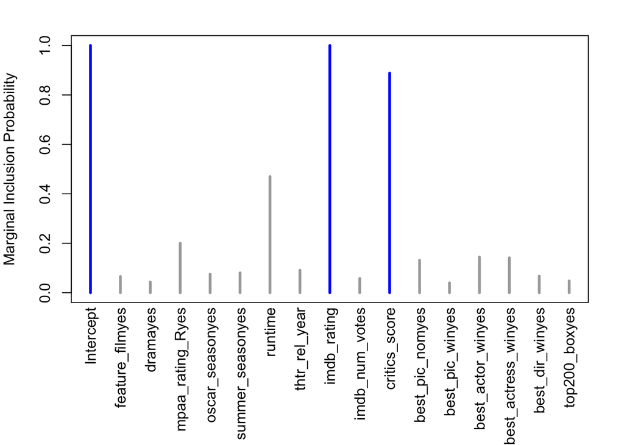

```r
par(mar=c(8,4,2,2))
plot(bma_audience, which = 4, ask = F, caption = "", sub.caption = "", col.in = "blue", col.ex = "darkgrey", lwd = 3)
```

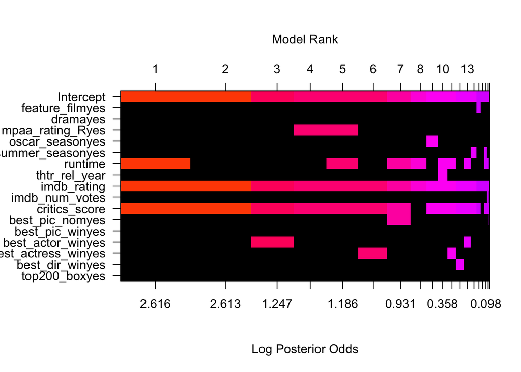

```r
image(bma_audience, rotate = FALSE)
```

It can be seen that the BAS algorithm is very efficient in producing parsimonious linear models thanks to the BIC prior.

Five new variables have been created in the previous section. The posterior distribution of their respective coefficients is plotted below. Vertical lines represent the probabilty that each coefficient is equal to zero.

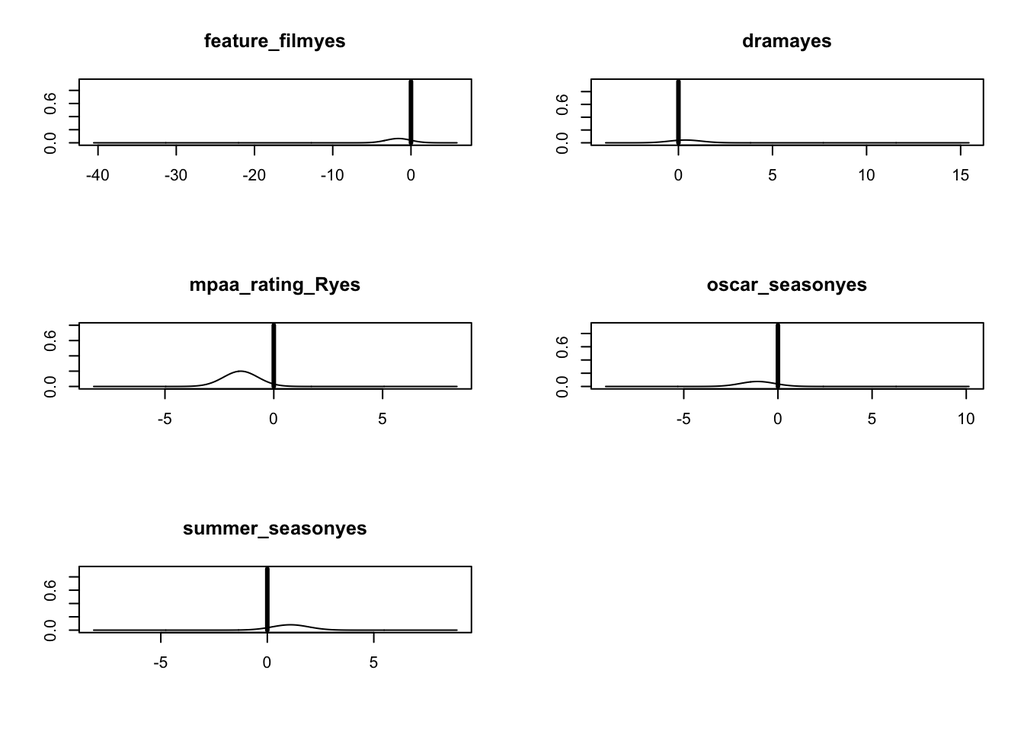

```r
coef_audience <- coefficients(bma_audience)

# plot posterior uncertainty in coefficients
par(mfrow = c(3,2))
plot(coef_audience, subset = 2:6, ask = FALSE)
```

As can be seen, all the newly created variables have coefficients that have at least $60\%$ probability to be equal to zero.

Another useful diagnostic test is to plot the distribution of residuals versus the predictions under the Bayesian Model Average (BMA) in order to verify that the residuals are randomly scattered with zero mean.

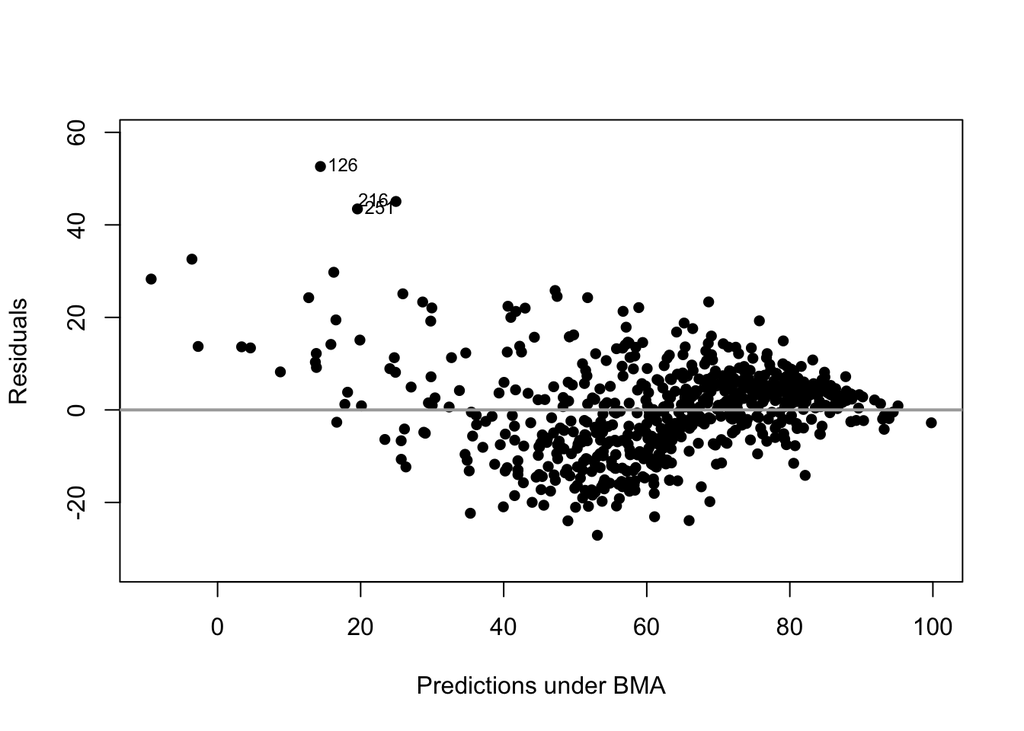

```r
plot(bma_audience, which = 1, add.smooth = F,
ask = F, pch = 16, sub.caption="", caption="")
abline(a = 0, b = 0, col = "darkgrey", lwd = 2)
```

The previous plot presents a typical *fan shape* which contradicts the hypothesis of random residuals. The predictions are more accurate for higher values of `audience_score`. This is due to the fact that, in this database, higher values of `audience_score` are much more frequent than the lower.

The marginal posterior means and standard deviations of the coefficients of the predictors, calculated under the BMA, are shown in the table below for completeness.

```r
coef(bma_audience)
```

```
##
##  Marginal Posterior Summaries of Coefficients:
##
##  Using  BMA
##
##  Based on the top  65536 models
##                      post mean   post SD     post p(B != 0)
## Intercept             6.235e+01   3.946e-01   1.000e+00
## feature_filmyes      -1.047e-01   5.643e-01   6.537e-02
## dramayes              1.604e-02   1.939e-01   4.320e-02
## mpaa_rating_Ryes     -3.036e-01   7.032e-01   1.998e-01
## oscar_seasonyes      -8.035e-02   3.773e-01   7.506e-02
## summer_seasonyes      8.705e-02   3.831e-01   8.042e-02
## runtime              -2.568e-02   3.118e-02   4.697e-01
## thtr_rel_year        -4.533e-03   1.819e-02   9.069e-02
## imdb_rating           1.498e+01   7.310e-01   1.000e+00
## imdb_num_votes        2.081e-07   1.313e-06   5.774e-02
## critics_score         6.297e-02   3.028e-02   8.886e-01
## best_pic_nomyes       5.068e-01   1.568e+00   1.312e-01
## best_pic_winyes      -8.503e-03   8.479e-01   3.985e-02
## best_actor_winyes    -2.877e-01   8.318e-01   1.443e-01
## best_actress_winyes  -3.088e-01   9.057e-01   1.413e-01
## best_dir_winyes      -1.195e-01   6.227e-01   6.694e-02
## top200_boxyes         8.648e-02   7.050e-01   4.762e-02
```

It is also interesting to calculate the $95\%$ credible intervals of the marginal posterior mean of the predictors coefficients, listed in the table below.

```r
confint(coef(bma_audience), level = 0.95)
```

```
##                             2.5%        97.5%          beta
## Intercept           61.586766472 6.313439e+01  6.234769e+01
## feature_filmyes     -0.987069022 1.964739e-02 -1.046908e-01
## dramayes             0.000000000 0.000000e+00  1.604413e-02
## mpaa_rating_Ryes    -2.125189474 0.000000e+00 -3.036174e-01
## oscar_seasonyes     -0.959525845 3.668782e-03 -8.034940e-02
## summer_seasonyes    -0.002785189 1.047905e+00  8.704545e-02
## runtime             -0.083622727 0.000000e+00 -2.567772e-02
## thtr_rel_year       -0.053978019 0.000000e+00 -4.532635e-03
## imdb_rating         13.701059595 1.658053e+01  1.498203e+01
## imdb_num_votes       0.000000000 2.077940e-06  2.080713e-07
## critics_score        0.000000000 1.056333e-01  6.296648e-02
## best_pic_nomyes      0.000000000 4.859138e+00  5.068035e-01
## best_pic_winyes      0.000000000 0.000000e+00 -8.502836e-03
## best_actor_winyes   -2.609038248 0.000000e+00 -2.876695e-01
## best_actress_winyes -2.806604075 0.000000e+00 -3.088382e-01
## best_dir_winyes     -1.639379749 2.668886e-03 -1.195011e-01
## top200_boxyes        0.000000000 0.000000e+00  8.648185e-02
## attr(,"Probability")
## [1] 0.95
## attr(,"class")
## [1] "confint.bas"
```

It can be noticed that only a few of the credible intervals, namely those of the coefficients of the Intercept and `imdb_rating`, do not contain the value zero.

## Part 5: Prediction

The predicting capabilities of the Bayesian regression model are tested on the 2016 movie *Jane Got a Gun*. The values for all the predictors can be found under the following links:

- [Rotten Tomatoes](https://www.rottentomatoes.com/m/jane_got_a_gun/)
- [Imdb](https://www.imdb.com/title/tt2140037/?ref_=nm_flmg_dr_9)
- [Wikipedia](https://en.wikipedia.org/wiki/Jane_Got_a_Gun).

A new data frame is then created.

```r
newmovie <- data.frame(feature_film = "yes",
                       drama = "yes",
                       mpaa_rating_R = "yes",
                       runtime = 98,
                       thtr_rel_year = 2016,
                       oscar_season = "no",
                       summer_season = "no",
                       imdb_rating = 5.9,
                       imdb_num_votes = 19806,
                       critics_score = 43,
                       best_pic_nom = "no",
                       best_pic_win = "no",
                       best_actor_win = "no",
                       best_actress_win = "yes",
                       best_dir_win = "no",
                       top200_box = "no")
```

The `audience_score` of this movie will be predicted using the four most significant models produced by the BAS algorithm. Along with the predicted values, $95\%$ credible intervals will be calculated. We begin with the BMA, which is obtained by averaging all models using their posterior probabilities. This is the best prediction under the squared error loss function.

```r
BMA.new = predict(bma_audience, newdata = newmovie, se.fit = TRUE, estimator = "BMA")
confint(BMA.new, parm = "pred")
```

```
##          2.5%    97.5%     pred
## [1,] 33.36289 73.24507 52.27368
## attr(,"Probability")
## [1] 0.95
## attr(,"class")
## [1] "confint.bas"
```

Then, we can apply the Best Predictive Model (BPM), which is the single model the predictions of which are closest to those of the BMA.

```r
BPM.new = predict(bma_audience, newdata = newmovie, se.fit = TRUE, estimator = "BPM")
confint(BPM.new, parm = "pred")
```

```
##          2.5%    97.5%     pred
## [1,] 32.37735 72.17001 52.27368
## attr(,"Probability")
## [1] 0.95
## attr(,"class")
## [1] "confint.bas"
```

Another option is to use the Median Probability Model (MPM), which includes all predictors whose marginal posterior inclusion probabilities are greater than 0.5.

```r
MPM.new = predict(bma_audience, newdata = newmovie, se.fit = TRUE, estimator = "MPM")
confint(MPM.new, parm = "pred")
```

```
##       2.5%    97.5%     pred
## [1,] 32.78 72.41878 52.59939
## attr(,"Probability")
## [1] 0.95
## attr(,"class")
## [1] "confint.bas"
```

Finally, we can use the Highest Probability Model (HPM).

```r
HPM.new = predict(bma_audience, newdata = newmovie, se.fit = TRUE, estimator = "HPM")
confint(HPM.new, parm = "pred")
```

```
##          2.5%    97.5%     pred
## [1,] 33.13699 72.61171 52.87435
## attr(,"Probability")
## [1] 0.95
## attr(,"class")
## [1] "confint.bas"
```

The difference both in terms of predicted value and in terms of credible interval among the four models is negligible for practical purposes. The real value of the `audience_score` of *Jane Got a Gun* is $37\%$. This value is noticeably lower than the $52\%$ predicted by all four models, but it is contained in all the corresponding credible intervals.

## Part 6: Conclusion

This exercise has highlighted the main steps in the construction of a Bayesian regression model, beginning with tidying the data and creating new variables, following with EDA, model generation, diagnostics and final application. Only a small subset of the variables present in the database turn out to be meaningful predictors of the `audience_score`. Furthermore, the distribution of `audience_score` in the database is significantly left-skewed, leading to more accurate predictions for higher values of this variable. The selected test case, on the contrary, has relatively low `audience_score`, leading to a poor accuracy of the prediction. It would be interesting to re-train a Bayesian regression model on a database in which the `audience_score` is more uniformly distributed.

Gabriele Grasso